# Analytic Programming Repository

Thomas R O’Neil (thomas.oneil@sydney.edu.au)

Last updated: September 27, 2024

# Content

## About

To collect scripts and ideas in one place, including:

- R scripts
- Flow scripts
- ImageJ scripts
- General functions from many languages
- Example workflows
- How to’s for things like Shiny, functions, packages, etc.

## Getting Started

This page will hopefully outline everything one needs to know to get started with the programmatic analysis we use in CVR.

### Downloading R

- R for [Windows](https://cran.csiro.au/bin/windows/) or [Mac](https://cran.csiro.au/bin/macosx/)
- [RStudio](https://posit.co/download/rstudio-desktop/)

### Installing packages

Most generic packages can be installed using the function

```r
install.packages("readxl")
```

However, bioinformatic packages are typically stored on bioconductor. When installing an R package from bioconductor, we need to first install BiocManager (a library that allows us to access bioconductor within R)

```r
install.packages("BiocManager")
install.packages("Seurat", version = "5.0.1")
```

**Packages only need to be downloaded once**. After this, you can load only the packages needed for each R session.

```r
library(ggplot2)
library(readxl)
library(Seurat)
```

**Notes:**

There is usually always some weird package issues that can occur when you first install packages from bioconductor. If you run into any issues, restart your R session after installing the packages.

If all else fails - Just use Google!

## General Uses of R

### General uses of R

In this section, I’ll add information and tips for using things like:

- ggplot
- dplyr
- ifelse, for, functions, and other.

## Custom Functions

### Custom Functions

#### Loading functions

Here I’ll drop custom functions that I contain in a github file.

It can be accessed using:

```r
source("https://raw.githubusercontent.com/DrThomasOneil/scrnaCVR/refs/heads/main/R/functions.r")
```

#### loadPack

This function runs automatically. It’ll load the packages that I typically use, which just saves me having to load packages manually everytime.

```r
loadPack <- function() {
  library(cli)
  cat("\n--------------------------------------\n")
  cat(style_bold(col_magenta("\n***Installing General Packages***\n\n")))
  not <- c(); not2 <- c()
  packages1 <- c("ggplot2", "rstudioapi", "rmarkdown", 'tidyr', "cli", "knitr", "dplyr", "Seurat","SeuratObject",
                 "DoubletFinder", "SeuratDisk", "flipPlots",'stringr', "crayon","Matrix", "cowplot", 'scater', "BiocParallel",
                 "ComplexHeatmap","readxl", "ggpubr")#, "Test")
  for (i in 1:length(packages1)){
    if(requireNamespace(packages1[i], quietly = TRUE)==F) {
      cat(paste(style_bold(col_red(packages1[i])), "has not been installed\n"))
      not <- c(not,i)
    } else {
      suppressWarnings(suppressMessages(library(as.character(packages1[i]), character.only = TRUE)))
      cat(col_yellow(packages1[i]), "is loaded!\n")
    }
  }
  cat("\n--------------------------------------\n")
  if (length(not) > 0){
    cat(style_bold(bg_red("\n  **IMPORTANT**  ")),
        style_bold(col_yellow("\n\nYou need to install: \n")),

        paste(paste(c(packages1[not]), collapse=", ")),
        "\n\n--------------------------------------",
        "\n\n Use:\n - install.packages(),\n - BiocManager::install() or, \n - use Google to find installation instructions.\n\n", style_bold(col_green("Then run this function again!\n\n")))
  } else {
    cat("",col_green(style_bold("\n All packages are loaded!\n\n Happy Coding! :)\n\n")))
  }
}
```

**Example use:**

```r
loadPack()
```

```
##
## --------------------------------------
##
## ***Installing General Packages***
##
## ggplot2 is loaded!
## rstudioapi is loaded!
## rmarkdown is loaded!
## tidyr is loaded!
## cli is loaded!
## knitr is loaded!
## dplyr is loaded!
## Seurat is loaded!
## SeuratObject is loaded!
## DoubletFinder has not been installed
## SeuratDisk has not been installed
## flipPlots is loaded!
## stringr is loaded!
## crayon is loaded!
## Matrix is loaded!
## cowplot is loaded!
## scater is loaded!
## BiocParallel is loaded!
## ComplexHeatmap is loaded!
## readxl is loaded!
## ggpubr is loaded!
##
## --------------------------------------
##
##   **IMPORTANT**
##
## You need to install:
##  DoubletFinder, SeuratDisk
##
## --------------------------------------
##
##  Use:
##  - install.packages(),
##  - BiocManager::install() or,
##  - use Google to find installation instructions.
##
##  Then run this function again!
```

#### plotSankey

This generates a sankey diagram using **Seurat data**. This might be useful to see how two vectors relate to each other. This was made by Brian Gloss.

An example of its use would be to transfer labels from one single cell dataset to another, and visualise how much of cluster aligns with the new annotations. And this can be done for multiple meta data columns.

```r
plotSankey<-function(seuratObj,idvar=c("varRes.0.3","emt_res.0.3")){
  require(flipPlots)
  message('try install_github("Displayr/flipPlots") if this doesnt work')
  require(dplyr)
  seuratObj@meta.data[,match(idvar,colnames(seuratObj@meta.data))] %>% arrange(.[,1]) %>% group_by_all() %>% summarise(COUNT = n()) ->> my.data
  #my.data<-as.factor(my.data[,1])
  SankeyDiagram(my.data[, -grep("COUNT",colnames(my.data))],link.color = "Source",weights = my.data$COUNT,,max.categories = 100)
}
```

**Example use:**

This might look strange, but its because the data had been integrated and this is just looking at the old annotations (Integrated_05) and the new labels of just one dataset.

```r
d <- readRDS("/Users/thomasoneil/Library/CloudStorage/OneDrive-SharedLibraries-TheUniversityofSydney(Staff)/HIV Pathogenesis & Mucosal Immunology - Documents/Kirstie/Anja/merged_Martin_GCA-SB-HealthyAdult_20220119_annotated_TO.rds")
plotSankey(d[,d$Integrated_05!=0], c("merged_clusters_anno", "Integrated_05", "Age"))
```

[interactive chart not shown]

#### Proportion plots

This is used to get proportions of some categorical value in groups. E.g. Clusters proportions of inflamed and uninflamed tissues.

```r
proportions <- function(data, ident.1, ident.2, position) {
  x<- FetchData(data,c(ident.1,ident.2))
  colnames(x) <- c('ident.2', 'ident.1')
  x%>%
    group_by(ident.1) %>%
    mutate(prop=1/length(ident.2)) %>%
    ungroup() %>%
    group_by(ident.2,ident.1) %>%
    summarise(totprop=sum(prop)) %>%

    ggplot(aes(x=ident.2,fill=ident.1,y=totprop)) +
      geom_bar(position=position, stat='identity') +
      theme(axis.text.x =element_text(angle = 45,hjust=1))+
      scale_y_continuous(name="Cluster Proportion")+
      theme_classic()
}
```

**Example use:**

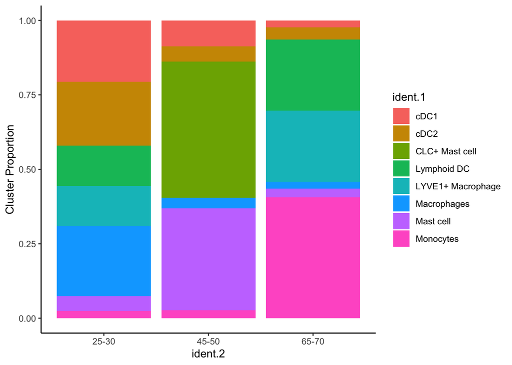

```r
proportions(d,
            "Age", # x axis
            "Integrated_05", # proportions
            "fill") # or stack
```

#### Process data

This function just summarises the standard processing of single cell RNA data. You can go in and uncomment the umap and tsne if you wish.

```r
process <- function(dat=dat, umap=T, tsne=F, dimuse = 1:30, features=2000, verbose=F, reduction.name=NULL){
  dat <- NormalizeData(dat, verbose=verbose)
  dat <- FindVariableFeatures(dat, nfeatures=features, verbose=verbose)
  dat <- ScaleData(dat, features=VariableFeatures(dat), verbose=verbose)
  dat <- RunPCA(dat, verbose=verbose, reduction.name = paste0("pca", reduction.name))
  if(umap) {
    dat <- RunUMAP(dat, dims=dimuse, verbose=verbose, reduction = paste0("pca", reduction.name), reduction.name = paste0("umap", reduction.name))
  }
  if(tsne){
     dat <- RunTSNE(dat, dims=dimuse, check_duplicates=F, verbose=verbose, reduction = paste0("pca", reduction.name),reduction.name = paste0("tsne", reduction.name))
  }
  return(dat)
}
```

**Example use:**

```r
seu_obj <- process(
  seu_obj,
  umap=T, tsne = F, # can change these to generate UMAPs or TSNEs. Default is UMAP only as its quicker.
  dimuse = 1:30,    # can set 1:whatever dimensions you want to use
  features = 2000,  # number of variable features to use. Adjust if using platforms like Xenium or CosMX
  verbose= F,       # change to T if you want to see the output as its running.
  reduction.name = NULL # change this if you want to add a unique name to your reductions. E.g. if you're testing a number of dimensions, features, or are running this pre-integration
)
```

#### Human Protein Atlas

Currently, this one is quite hideous. I downloaded the protein and the RNA data from the [Human Protein Atlas](https://www.proteinatlas.org/). This function is basically used to get a general idea of what an unknown gene might be associated with.

I then filtered quite a bit out. The R script used to generate the data can be found [here](https://github.com/DrThomasOneil/LabCode/tree/main/HPA). (I think I filtered out tissues and cell-types not relevant to our group)

When you source these functions from Github, this function reads in the data as an object `HPA` and loads the function `hpa`

```r
hpa <- function(gene="CD14", log=F) {
  if(log==T) {
    p2 <- ggplot(HPA[[1]][HPA[[1]]$Gene.name==gene,], aes(Cell.type, log(Exp), fill=Tissue))+geom_col()+theme_classic()+RotatedAxis()+NoLegend()+ylab("Protein Exp")
    p1 <- ggplot(HPA[[1]][HPA[[1]]$Gene.name==gene,], aes(Tissue, log(Exp), fill=Tissue))+geom_col()+theme_classic()+RotatedAxis()+NoLegend()+geom_vline(xintercept = c(4.5,7.5))+ggtitle(gene)+ylab("Protein Exp")
    p3 <-ggplot(HPA[[2]][HPA[[2]]$Gene.name==gene,], aes(Cell.type, log(nTPM+1), fill=Cell.type))+geom_col()+theme_classic()+RotatedAxis()+NoLegend()+geom_vline(xintercept = c(4.5,6.5,8.5,13.5,15.5,17.5))
    p4 <-ggplot(HPA[[3]][HPA[[3]]$Gene.name==gene,], aes(Cell.type, log(nTPM+1), fill=Tissue))+geom_col()+theme_classic()+RotatedAxis()+theme(legend.position = 'top', legend.direction= "horizontal")+geom_vline(xintercept = c(2.5,4.5,6.5,8.5,10.5))
  }
  else{
    p2 <- ggplot(HPA[[1]][HPA[[1]]$Gene.name==gene,], aes(Cell.type, Exp, fill=Tissue))+geom_col()+theme_classic()+RotatedAxis()+NoLegend()+ylab("Protein Exp")
    p1 <- ggplot(HPA[[1]][HPA[[1]]$Gene.name==gene,], aes(Tissue, Exp, fill=Tissue))+geom_col()+theme_classic()+RotatedAxis()+NoLegend()+geom_vline(xintercept = c(4.5,7.5))+ggtitle(gene)+ylab("Protein Exp")
    p3 <-ggplot(HPA[[2]][HPA[[2]]$Gene.name==gene,], aes(Cell.type, nTPM, fill=Cell.type))+geom_col()+theme_classic()+RotatedAxis()+NoLegend()+geom_vline(xintercept = c(4.5,6.5,8.5,13.5,15.5,17.5))
    p4 <-ggplot(HPA[[3]][HPA[[3]]$Gene.name==gene,], aes(Cell.type, nTPM, fill=Tissue))+geom_col()+theme_classic()+RotatedAxis()+theme(legend.position = 'top', legend.direction= "horizontal")+geom_vline(xintercept = c(2.5,4.5,6.5,8.5,10.5))
  }
  print(plot_grid(p1,p2,p3,p4))
}
```

**Example use:**

**Top panels are protein**: Protein expression a bit strange. As I understand it, they’ve scored its expression from 1-3. On the left is scored per tissue, and on the right stacked tissue scores per cell type.

**Bottom panels are RNA**: Left is celltype only. Right should be similar but stacked with tissues.

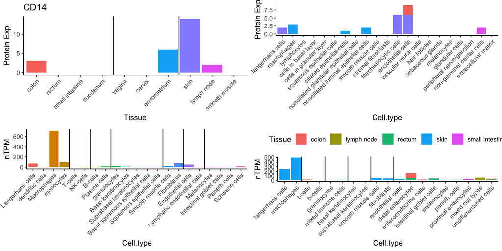

```r
hpa("CD14")
```

#### Label transfer Heatmap

This one has a lot of options but does quite a bit under the hood.

It needs two RNA datasets tour query data, a reference data. There are then several options

- the identities you want to compare - default will just be the current `idents`.
- `norm` will let you choose whether to scale prediction scores by the max predicted score. Can be misleading, which is why the default is `false`.
- `crow` and `ccol` are about clustering rows and columns by similarities. Turn these off if you have a preferred order you want.
- `return.plot` and `return.seurat` do not work together. If both `false` it will only return a plot. See example uses below.
- `col.name` will let you set a custom column name for `return.seurat`. E.g. predicted_GCA.
- `var.feat` is empty by default, which will use the reference variable features. Otherwise, you can specify features to use for integration.

```r
predictHeat <- function(ref, query, refID = "ident", queryID = "ident", norm=F, crow=T,ccol=T, return.plot=F, return.seurat=F, col.name="predictedID", var.feat="") {
  if(length(var.feat)==1) {
    predictions <- TransferData(
      anchorset = FindTransferAnchors(reference = ref, query = query, features=VariableFeatures(ref)),
      refdata = FetchData(ref, refID)[,1]
    )
  } else {
    predictions <- TransferData(
      anchorset = FindTransferAnchors(reference = ref, query = query, features=var.feat),
      refdata = FetchData(ref, refID)[,1]
    )
  }
  predictions$orig =FetchData(query, queryID)[,1]
  df <- as.data.frame(matrix(data=NA,ncol=length(unique(predictions$orig)), nrow=length(unique(predictions$predicted.id))))
  colnames(df) = unique(predictions$orig);
  rownames(df) = paste0("prediction.score.",gsub(" ", ".",unique(predictions$predicted.id)))
  df2 <- as.data.frame(matrix(data=NA,ncol=length(unique(predictions$orig)), nrow=length(unique(predictions$predicted.id))))
  colnames(df2) = unique(predictions$orig);
  rownames(df2) = paste0("prediction.score.",gsub(" ", ".",unique(predictions$predicted.id)))
  for(col in 1:ncol(df)) {
    for(row in 1:nrow(df)){
      x = mean(predictions[predictions$orig==colnames(df)[col], rownames(df)[row]])
      x2 = mean(predictions[predictions$orig==colnames(df)[col],
                            rownames(df)[row]]/
                  predictions[predictions$orig==colnames(df)[col],
                              "prediction.score.max"])
      if(is.na(x) | is.infinite(x)){x=0}
      if(is.na(x2) | is.infinite(x2)){x2=0}
      df[row,col] <-x
      df2[row,col] <-x2
    }
  }
  if (norm) {df = df2}
  if(!ccol) {ccol = F}
  if(!crow) {crow =F}
  print(ComplexHeatmap::Heatmap(na.omit(df), cluster_columns = ccol, cluster_rows = crow))
  #dont return both a metatable
  if(return.plot*return.seurat ==1) {
    cat(style_bold(col_red("\n***ERROR***\n\n")))
    cat(style_bold(col_yellow("\n***ERROR***\n\n")))
  } else {
    if(return.plot){
      plot = ComplexHeatmap::Heatmap(na.omit(df), cluster_columns = ccol, cluster_rows = crow)
      return(plot)
    }
    if(return.seurat){
      query <- AddMetaData(query, metadata = predictions$predicted.id, col.name=col.name)
      return(query)
    }
  }
}
```

**Example use:**

Just output the plot

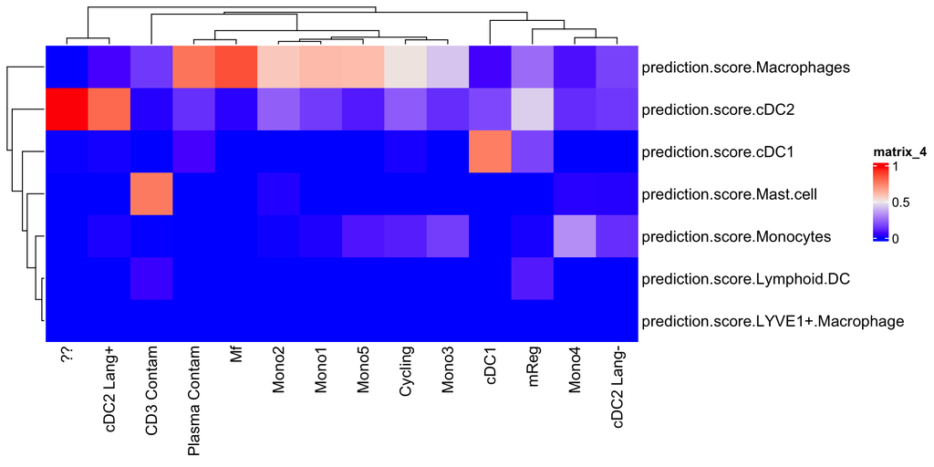

```r
plot <- predictHeat(ref, query,
                     refID = "Integrated_05", queryID = "merged_clusters_anno",
                     norm=F,
                     crow=T,ccol=T,
                     return.plot=T, # as TRUE will assign the plot
                     return.seurat=F,
                     col.name="predictedID", var.feat="")
```

Assign a nee column called `predictedID` to the query dataset - the function outputs the plot anyways. But then we can use something like plotSankey to see how the cells were labelled.

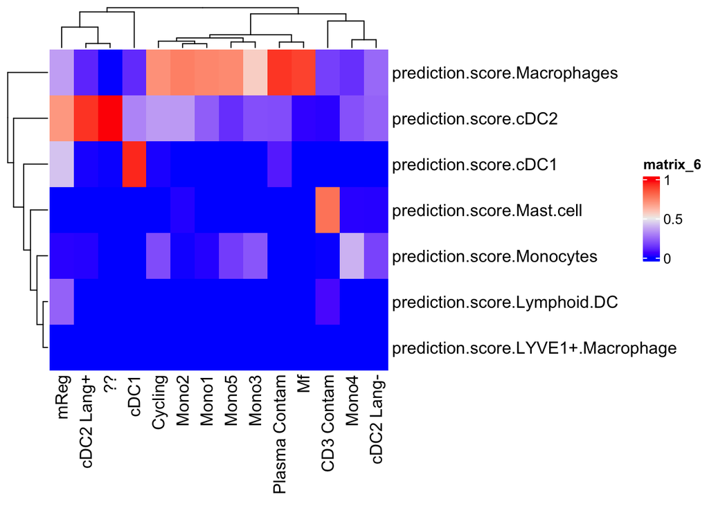

```r
query <- predictHeat(ref, query,
                     refID = "Integrated_05", queryID = "merged_clusters_anno",
                     norm=T,
                     crow=T,ccol=T,
                     return.plot=F,
                     return.seurat=T, #as TRUE will save the predicted scores as 'predictedID'
                     col.name="predictedID", var.feat="")
```

```r
plotSankey(query, c("merged_clusters_anno", "predictedID"))
```

[interactive chart not shown]

#### Top DE markers

This is just summarised script for finding the top differentially expressed markers

```r
topm <- function(data, min.diff.pct = 0.01, n=40, logfc = 0.1) {
  FindAllMarkers(data, only.pos=T, min.diff.pct = min.diff.pct, logfc.threshold = logfc) %>%
    filter(p_val_adj <0.0001) %>%
    group_by(cluster) %>%
    top_n(n=n, wt = avg_log2FC)
}
```

**Example use:**

```r
top20markers <- topm(ref,
                     min.diff.pct = 0.1,
                     logfc = 0.2,
                     n=20)
head(top20markers)
```

## scRNA

### Single Cell Data Analysis

There are a few things to summarise here and I’ll cover most of the important information, such as:

- how to load in data
- standard processing pipeline
- QC
- Integation
- Differential Analysis
- Visualisations
- Exporting data

#### Loading in new data

To do

## Visium

NULL

## CosMX

NULL

## Flow

NULL

## ImageJ

NULL

## RShiny

NULL

## Current working protocols

NULL